# 数学建模

### 模型知识点

### 优化模型-线性规划-Pulp库使用-线性回归案例(en)

**Wang Haihua**

🚅 🚋😜 🚑 🚔

## Exercise: Linear regression minimizing $\ell_1$-error

**Goal:** Solve linear regression with an $\ell_1$-error function using a linear program.

**Additional resources:** For an introduction on regression, see https://stat.ethz.ch/education/semesters/ss2016/regression/Regression.pdf.

A researcher would like to know if a child's height $H$ (in cm) can be predicted by their age $A$ (in years). In other words, she would like to know if there is any relationship between $A$ and $H$. She begins by observing the age and height of fifteen children. Her data is stored below (the first child was age 1 with height 73.2, the second child was age 1 with height 73.3, etc.).

```python
# Observed ages in years
obs_age = [1,1,2,2,3,4,4,5,6,7,7,8,9,9,10]

# Observed heights in cm
obs_ht = [73.2,73.3,75.1,77.4,80.1,85.7,84.0,89.1,100.2,105.3,112.2,115.0,125.1,135.2,150.7]
```

We can visualize this data using the `matplotlib` library in Python. The `plt.scatter` plots the individual data points.

We can also draw different lines through the data to visualize a linear relationship.

**Note:** There are many ways to plot a line in `matplotlib`. One method involves using the `numpy` Python package.

Run the following code to plot the data and to draw the lines $H = 7A+65$ and $H = 5.75A+70$.

```python
# Import Python's plotting tools (matplotlib) and math tools (numpy)
import matplotlib.pyplot as plt
import numpy as np
%matplotlib inline

# Plot the points
plt.scatter(obs_age,obs_ht)

# Draw the line H = 7A+65
A = np.linspace(1,10,100)
H = 7*A+65
plt.plot(A,H, color = 'red')

# Draw the line H = 5.75A+70
H = 5.75*A+70
plt.plot(A,H, color = 'green')
```

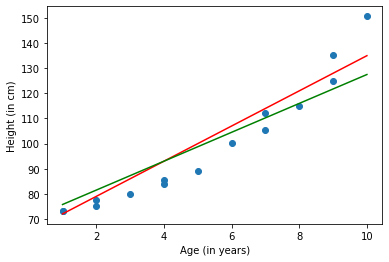

```python
plt.xlabel("Age (in years)")
plt.ylabel("Height (in cm)")
plt.show()
```

Both lines $H = 7A + 65$ and $H = 5.75A + 70$ seem to capture some of the correlation between `obs_ages` and `obs_ht`. However, which line is the better choice? Regression measures this with a loss function.

Given values $\alpha, \beta \in \mathbb{R}$, we say that the $\ell_1$-error of the line $H = \beta A + \alpha$ is equal to $$ \displaystyle \sum_{i=1}^{15} |\text{obs_ht}_{~i} - (\beta \times \text{obs_age}_{~i} + \alpha)|. $$

The line $H = 7A + 65$ has an $\ell_1$ error of $90.19$, and the line $H = 5.75A + 70$ has an $\ell_1$ error of $100.80$.

**Your first task:** Write an LP that finds parameters $\alpha$ and $\beta$ so that the line $H = \beta A + \alpha$ minimizes the $\ell_1$-error.  
Implement this LP and solve it. Also, plot the optimal line $H$ that you found together with the data.

```python
import pulp
num_points = len(obs_age)
```

```python
# Problem and variables
problem1 = pulp.LpProblem('task1', sense=pulp.LpMinimize)
alpha = pulp.LpVariable('alpha')
beta = pulp.LpVariable('beta')
residuals = [pulp.LpVariable(f'residual_{idx}', lowBound=0) for idx in range(num_points)]

# Minimize sum of absolute residuals
problem1.objective = pulp.lpSum(residuals)

# s.t. the residual variables correspond to the absolute differences
for idx, (residual, height, age) in enumerate(zip(residuals, obs_ht, obs_age)):
    # Due to minimzation an inequality is sufficient, i.e. the optimal value attains the bound
    relative_difference = height - (beta * age + alpha)
    problem1.addConstraint(residual >= relative_difference, f'residual_{idx}_a')
    problem1.addConstraint(residual >= -relative_difference, f'residual_{idx}_b')
```

```
Solution status: Optimal
Optimal α: 60.814286
Optimal β: 7.1428571
Optimal sum of absolute residuals: 73.4142858
```

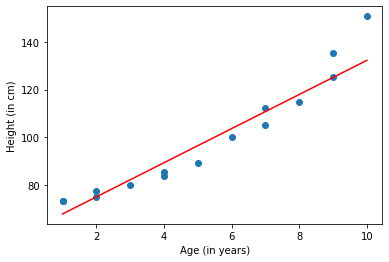

```python
# Solve problem
status = problem1.solve()
print('Solution status:', pulp.LpStatus[status])

print('Optimal \u03B1:', alpha.value())
print('Optimal \u03B2:', beta.value())
print('Optimal sum of absolute residuals:', pulp.value(problem1.objective))

# Plot solution
plt.scatter(obs_age,obs_ht)
A = np.linspace(1,10,100)
H = beta.value() * A + alpha.value()
plt.plot(A,H, color = 'red')
plt.xlabel("Age (in years)")
plt.ylabel("Height (in cm)")
plt.show()
```

Perhaps the relationship between age and height is not linear. In fact the data in the previous plot seems to suggest that the relationship is more quadratic. We can also use linear programming to solve this quadratic regression problem!

Given values $\alpha_0, \alpha_1, \alpha_2 \in \mathbb{R}$, we say that the $\ell_1$-error of the quadratic function $H = \alpha_2 A^2 + \alpha_1 A + \alpha_0$ is equal to $$ \displaystyle \sum_{i=1}^{15} |\text{obs_ht}_{~i} - (\alpha_2 \times \text{obs_age}_{~i}^2 + \alpha_1 \times \text{obs_age}_{~i} + \alpha_0)|. $$

**Your second task:** Write an LP that finds parameters $\alpha_0$, $\alpha_1$ and $\alpha_2$ so that the quadratic function $H = \alpha_2 A^2 + \alpha_1 A + \alpha_0$ minimizes the $\ell_1$-error.  
Implement this LP and solve it. Also, plot the optimal curve $H$ that you found together with the data.

```python
# Problem and variables
problem2 = pulp.LpProblem('task2', sense=pulp.LpMinimize)
alphas = [pulp.LpVariable(f'alpha_{idx}') for idx in range(3)]
residuals = [pulp.LpVariable(f'residual_{idx}', lowBound=0) for idx in range(num_points)]

# Minimize sum of absolute residuals
problem2.objective = pulp.lpSum(residuals)

# s.t. the residual variables correspond to the absolute differences
# Now with the quadratic function
for idx, (residual, height, age) in enumerate(zip(residuals, obs_ht, obs_age)):
    # Due to minimzation an inequality is sufficient, i.e. the optimal value attains the bound
    relative_difference = height - (alphas[2] * np.square(age) + alphas[1] * age + alphas[0])
    problem2.addConstraint(residual >= relative_difference, f'residual_{idx}_a')
    problem2.addConstraint(residual >= -relative_difference, f'residual_{idx}_b')
```

```python
# Solve problem
status = problem2.solve()
print('Solution status:', pulp.LpStatus[status])

for idx in range(2, -1, -1):
    print(f'Optimal \u03B1_{idx}:', alphas[idx].value())
print('Optimal sum of absolute residuals:', pulp.value(problem2.objective))
```

```
Solution status: Optimal
Optimal α_2: 0.83416667
Optimal α_1: -0.60416667
Optimal α_0: 73.07
Optimal sum of absolute residuals: 31.841666633
```

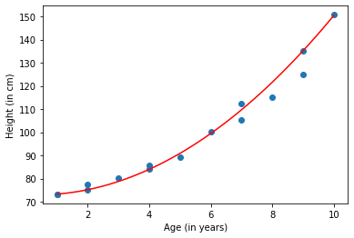

```python
# Plot solution
plt.scatter(obs_age,obs_ht)
A = np.linspace(1,10,100)
H = alphas[2].value() * np.square(A) + alphas[1].value() * A + alphas[0].value()
plt.plot(A,H, color = 'red')
plt.xlabel("Age (in years)")
plt.ylabel("Height (in cm)")
plt.show()
```